# Regression Analysis of Sahlins and Ophthalmology Data Sets

Elizabeth Kalmanovich

6/7/21

## Sahlins

### Scatterplot

```r
#install.packages('carData')
library(carData)
summary(Sahlins)
```

```
##    consumers         acres
##  Min.   :1.000   Min.   :1.290
##  1st Qu.:1.275   1st Qu.:2.005
##  Median :1.490   Median :2.190
##  Mean   :1.523   Mean   :2.162
##  3rd Qu.:1.653   3rd Qu.:2.370
##  Max.   :2.300   Max.   :3.090
```

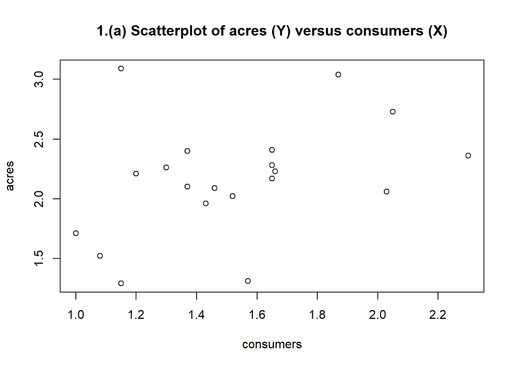

```r
plot(Sahlins$consumers, Sahlins$acres, pch = 1,
     main= "1.(a) Scatterplot of acres (Y) versus consumers (X)", xlab= "consumers", ylab= "acres")
```

The data seems to be pretty randomly dispersed, with potentially a slightly positive relationship. There are no strong linear patterns visible. One thing that can be noted is most of the y-axis data is between 2.0 and 2.5 acres. A household with a lower consumer/gardener ratio tends to cultivate less land per gardener. There is one point at (1.15, 3.09), where the consumer ratio is low but a very high amount of acres is cultivated.

### Grouping

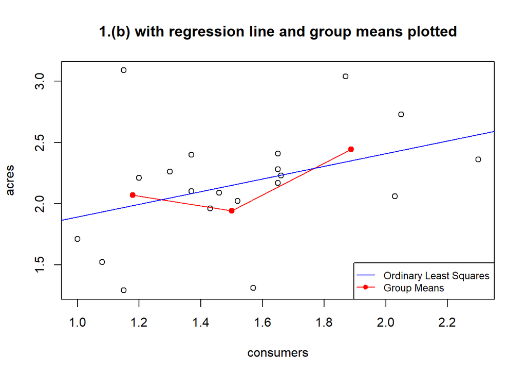

```r
group1 <- Sahlins[1:7,]
group2 <- Sahlins[8:13,]
group3 <- Sahlins[14:20,]

plot(Sahlins$consumers, Sahlins$acres, pch = 1,
     main= "1.(b) with regression line and group means plotted", xlab= "consumers", ylab= "acres")
points(mean(group1$consumers), mean(group1$acres), col="red", pch = 19)
points(mean(group2$consumers), mean(group2$acres), col="red", pch = 19)
points(mean(group3$consumers), mean(group3$acres), col="red", pch = 19)
segments(x0 = mean(group1$consumers), y0 = mean(group1$acres), x1 = mean(group2$consumers), y1 = mean(group2$acres), col = "red")
segments(x0 = mean(group2$consumers), y0 = mean(group2$acres), x1 = mean(group3$consumers), y1 = mean(group3$acres), col = "red")
abline(lm(Sahlins$acres~Sahlins$consumers), col= "blue")
legend("bottomright",c("Ordinary Least Squares","Group Means"),cex=.8,col=c("blue","red"),pch=c(NA,19), lty = 1)
```

Both lines show a slightly increasing relationship between consumers and acres. The reason that the red line dips from group1 to group2 is because there is an outlier in group 2 with significantly low acres/gardener ratio. Otherwise both lines do help in describing the relationship, maybe the simple regression more so because it is not so clearly affected by the outlier.

### Boxplot

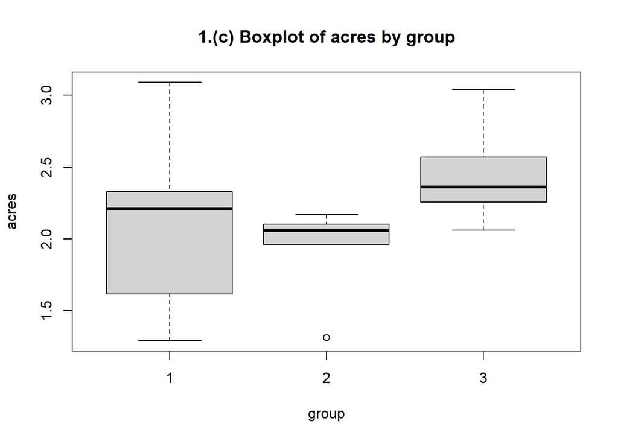

```r
Sahlins$group <- cut(as.numeric(rownames(Sahlins)), breaks=c(0, 7, 13, 20), labels=1:3)
boxplot(acres~group,data = Sahlins, xlab = "group", ylab = "acres", main = "1.(c) Boxplot of acres by group")
```

There is an outlier in group 2 where the acre cultivation is significantly lower than similar consumer ratios. It shows in the first group with the lowest consumer/gardener ratio, there is the largest variety of amount of land cultivated per gardener. In group 3, the mean of the land cultivated is higher than the other two groups, along with most data points.

### Regression

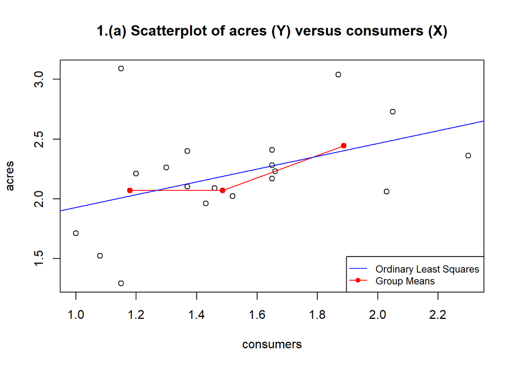

```r
newSahlins <- Sahlins[-c(12),]
newgroup1 <- newSahlins[1:7,]
newgroup2 <- newSahlins[8:12,]
newgroup3 <- newSahlins[13:19,]

plot(newSahlins$consumers, newSahlins$acres, pch = 1,
     main= "1.(a) Scatterplot of acres (Y) versus consumers (X)", xlab= "consumers", ylab= "acres")
points(mean(newgroup1$consumers), mean(newgroup1$acres), col="red", pch = 19)
points(mean(newgroup2$consumers), mean(newgroup2$acres), col="red", pch = 19)
points(mean(newgroup3$consumers), mean(newgroup3$acres), col="red", pch = 19)
segments(x0 = mean(newgroup1$consumers), y0 = mean(newgroup1$acres), x1 = mean(newgroup2$consumers), y1 = mean(newgroup2$acres), col = "red")
segments(x0 = mean(newgroup2$consumers), y0 = mean(newgroup2$acres), x1 = mean(newgroup3$consumers), y1 = mean(newgroup3$acres), col = "red")
abline(lm(newSahlins$acres~newSahlins$consumers), col= "blue")
legend("bottomright",c("Ordinary Least Squares","Group Means"),cex=.8,col=c("blue","red"),pch=c(NA,19), lty = 1)
```

The new means follow a stronger linear positive pattern than before. The linear relationship between the means of the groups falls closely alongside the simple regression line. The regression line also fits the remaining points better than before.

## Ophthalmology

### Plot LOESS Lines

```r
op <- read.csv("ophthalmology.csv")
names(op)
```

```
##  [1] "PatientNo"                "Age.in.years"
##  [3] "Gender"                   "pct.Burns"
##  [5] "Weight.kg"                "Periocular.Burn"
##  [7] "Survived"                 "Pressure.1.R"
##  [9] "Pressure.1.L"             "Pressure.2.R"
## [11] "Pressure.2.L"             "Pressure.3.R"
## [13] "Pressure.3.L"             "Canthotomy"
## [15] "Post.Canth.Pressure.R"    "Post.Canth.Pressure.L"
## [17] "Topical.med"              "Intubation"
## [19] "Extrem.hypoperf"          "Decompressive.Laparotomy"
## [21] "Baxter.pred.fluid.at.24h" "Fluid.at.24h"
```

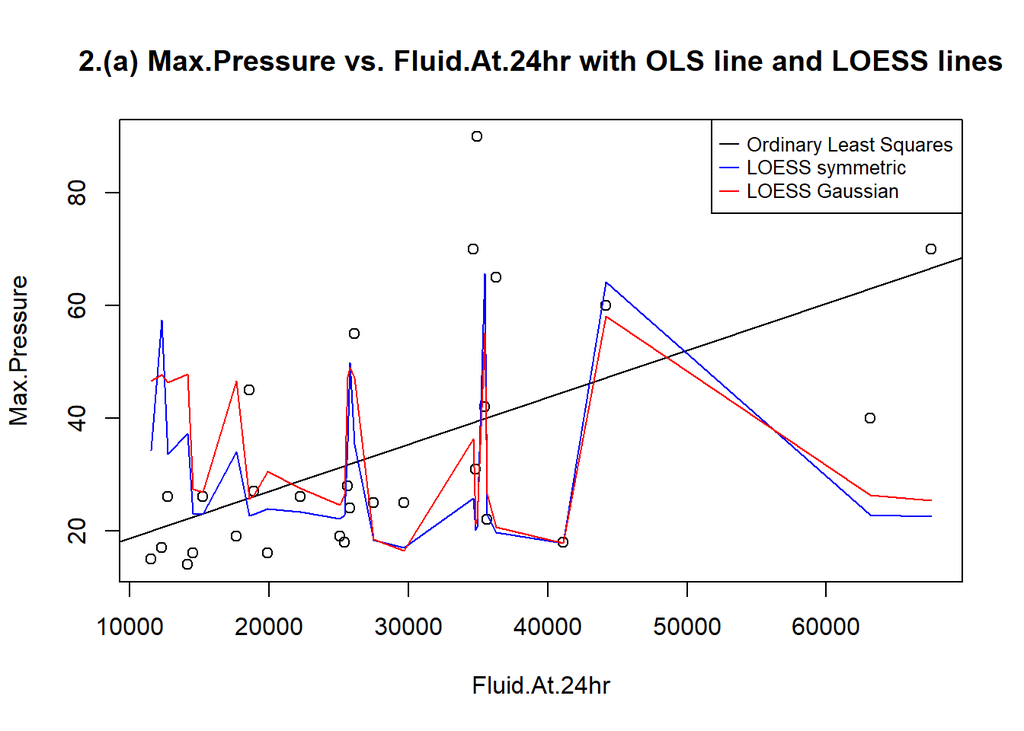

```r
op[is.na(op)] = 0
op$Max.Pressure <- apply(X=op[8:13], MARGIN=1, FUN=max)

plot(op$Fluid.at.24h, op$Max.Pressure, pch = 1,
     main= "2.(a) Max.Pressure vs. Fluid.At.24hr with OLS line and LOESS lines", xlab= "Fluid.At.24hr", ylab= "Max.Pressure")
legend("topright",c("Ordinary Least Squares","LOESS symmetric", "LOESS Gaussian"),cex=.8,col=c("black", "blue","red"),pch=151)
abline(lm(op$Max.Pressure~op$Fluid.at.24h), col= "black")
#lines(sort(op$Fluid.at.24h), predict(loess(op$Max.Pressure ~ op$Fluid.at.24h), family="gaussian" ),col="green")
out1 <- loess(Max.Pressure ~ Fluid.at.24h,data=op, family="symmetric")
out2 <- loess(Max.Pressure ~ Fluid.at.24h,data=op, family="gaussian")
lines(sort(op$Fluid.at.24h), predict(out1), col="blue")
lines(sort(op$Fluid.at.24h), predict(out2), col="red")
```

The data could be very weakly linear, but the points seems pretty scattered. The least squares regression is positive, but the LOESS lines don’t have a notable direction or pattern. It should be noted that in the 1st and 2nd quartiles of the data, people with lower Fluid.At.24h consistently have lower max pressures. On the other hand, the max pressure become much less predictabe for people with higher Fluid at 24 hr rates.

### LOESS Using Log

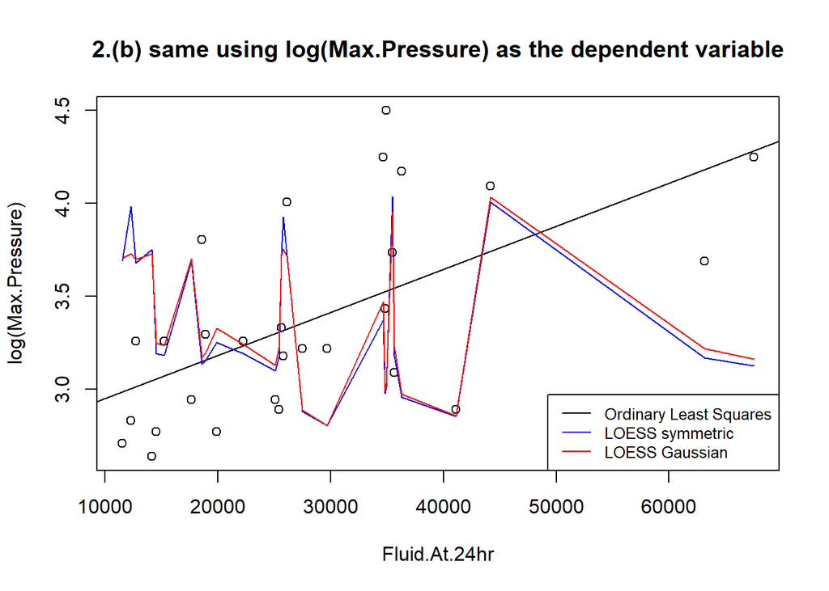

```r
plot(op$Fluid.at.24h, log(op$Max.Pressure), pch = 1,
     main= "2.(b) same using log(Max.Pressure) as the dependent variable", xlab= "Fluid.At.24hr", ylab= "log(Max.Pressure)")
legend("bottomright",c("Ordinary Least Squares","LOESS symmetric", "LOESS Gaussian"),cex=.8,col=c("black", "blue","red"),lty=1)
abline(lm(log(op$Max.Pressure)~op$Fluid.at.24h), col= "black")
out1 <- loess(log(op$Max.Pressure) ~ Fluid.at.24h,data=op, family="symmetric")
out2 <- loess(log(op$Max.Pressure) ~ Fluid.at.24h,data=op, family="gaussian")
lines(sort(op$Fluid.at.24h), predict(out1), col="blue")
lines(sort(op$Fluid.at.24h), predict(out2), col="red")
```

The symmetric and gaussian LOESS curves are more similar, and overlap more than in part a. The analysis is basically the same, but the points are less crammed in b, so the graph might be easier to interpret.

### More Transformations

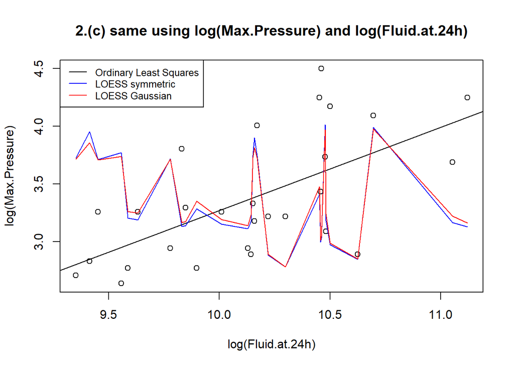

```r
plot(log(op$Fluid.at.24h), log(op$Max.Pressure), pch = 1,
     main= "2.(c) same using log(Max.Pressure) and log(Fluid.at.24h)", xlab= "log(Fluid.at.24h)", ylab= "log(Max.Pressure)")
legend("topleft",c("Ordinary Least Squares","LOESS symmetric", "LOESS Gaussian"),cex=.8,col=c("black", "blue","red"),lty=1)
abline(lm(log(op$Max.Pressure)~log(op$Fluid.at.24h)), col= "black")
out1 <- loess(log(op$Max.Pressure) ~ log(op$Fluid.at.24h),data=op, family="symmetric")
out2 <- loess(log(op$Max.Pressure) ~ log(op$Fluid.at.24h),data=op, family="gaussian")
lines(sort(log(op$Fluid.at.24h)), predict(out1), col="blue")
lines(sort(log(op$Fluid.at.24h)), predict(out2), col="red")
```

A linear patter is much more apparent after logging both variables. The regression line follows the points smoothly with a positive relationship. The LOESS curves are still a bit wacky to me, and they don’t appear to correlate with the points better than before taking the log.